# Colon FACS Notebook

Specify the tissue of interest, run the boilerplate code which sets up the functions and environment, load the tissue object.

```
[1] "Scaling data matrix"
```

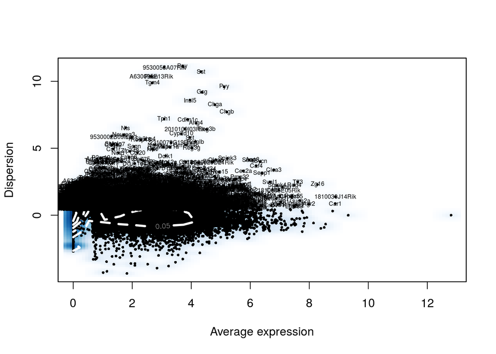

```r
tissue_of_interest = "Colon"
library(here)
source(here("00_data_ingest", "02_tissue_analysis_rmd", "boilerplate.R"))
tiss <- load_tissue_facs(tissue_of_interest)
```

Visualize top genes in principal components

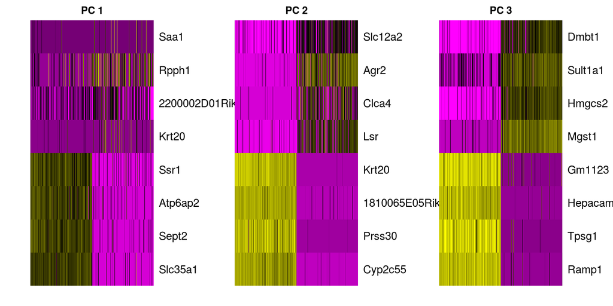

Later on (in FindClusters and TSNE) you will pick a number of principal components to use. This has the effect of keeping the major directions of variation in the data and, ideally, supressing noise. There is no correct answer to the number to use, but a decent rule of thumb is to go until the plot plateaus.

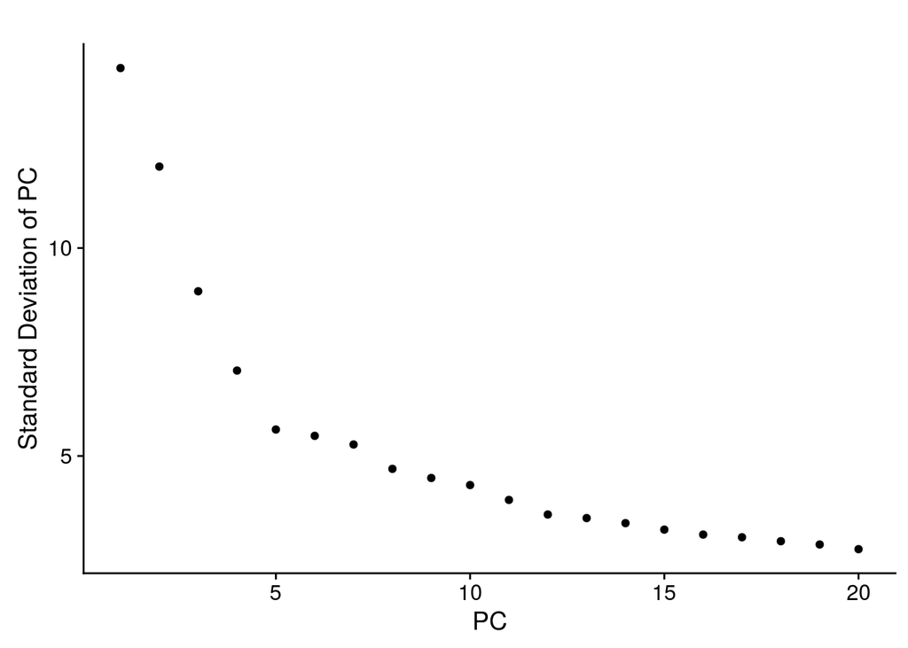

```r
PCElbowPlot(object = tiss)
```

Choose the number of principal components to use.

```r
# Set number of principal components.
n.pcs = 20
```

The clustering is performed based on a nearest neighbors graph. Cells that have similar expression will be joined together. The Louvain algorithm looks for groups of cells with high modularity–more connections within the group than between groups. The resolution parameter determines the scale…higher resolution will give more clusters, lower resolution will give fewer.

For the top-level clustering, aim to under-cluster instead of over-cluster. It will be easy to subset groups and further analyze them below.

```r
# Set resolution
res.used <- 0.7

tiss <- FindClusters(object = tiss, reduction.type = "pca", dims.use = 1:n.pcs,
    resolution = res.used, print.output = 0, save.SNN = TRUE)
```

To visualize

```r
# If cells are too spread out, you can raise the perplexity. If you have few cells, try a lower perplexity (but never less than 10).
tiss <- RunTSNE(object = tiss, dims.use = 1:n.pcs, seed.use = 10, perplexity=30)
```

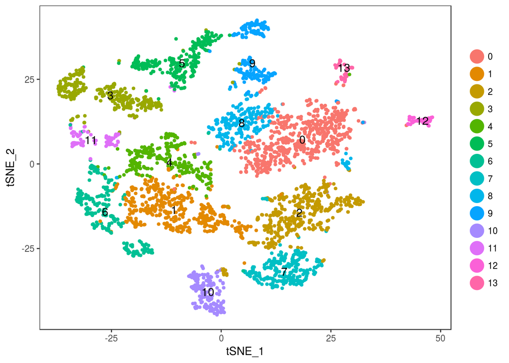

```r
# note that you can set do.label=T to help label individual clusters
TSNEPlot(object = tiss, do.label = T)
```

Check expression of genes of interset.

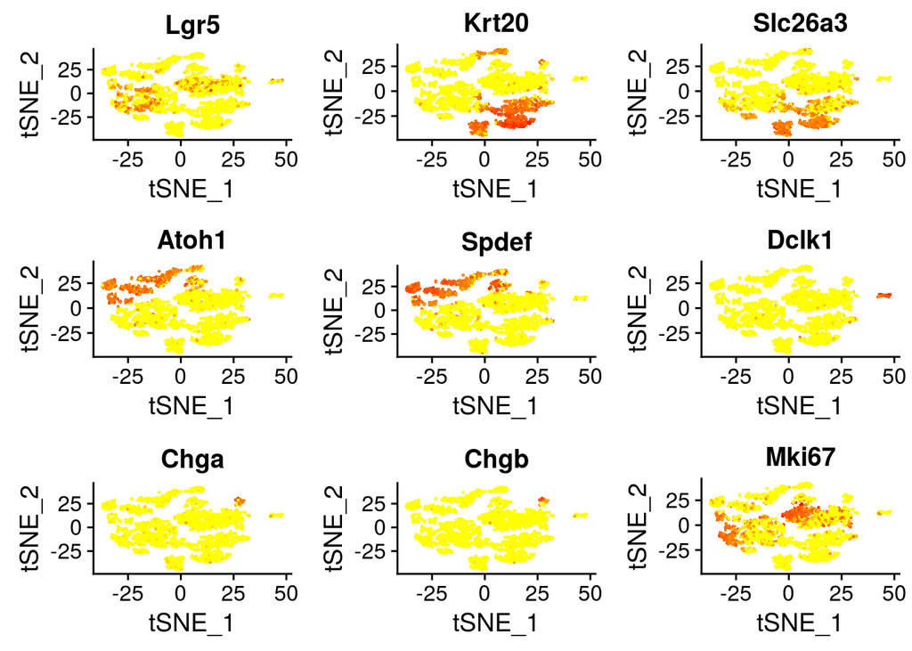

```r
#{r, echo=FALSE, fig.height=16, fig.width=12}
genes_to_check = c('Lgr5', 'Krt20', 'Slc26a3', 'Atoh1', 'Spdef', 'Dclk1', 'Chga', 'Chgb', 'Mki67')

#FeaturePlot(tiss, genes_to_check, pt.size = 1, nCol = 3)
FeaturePlot(tiss, genes_to_check, pt.size = 0.5)
```

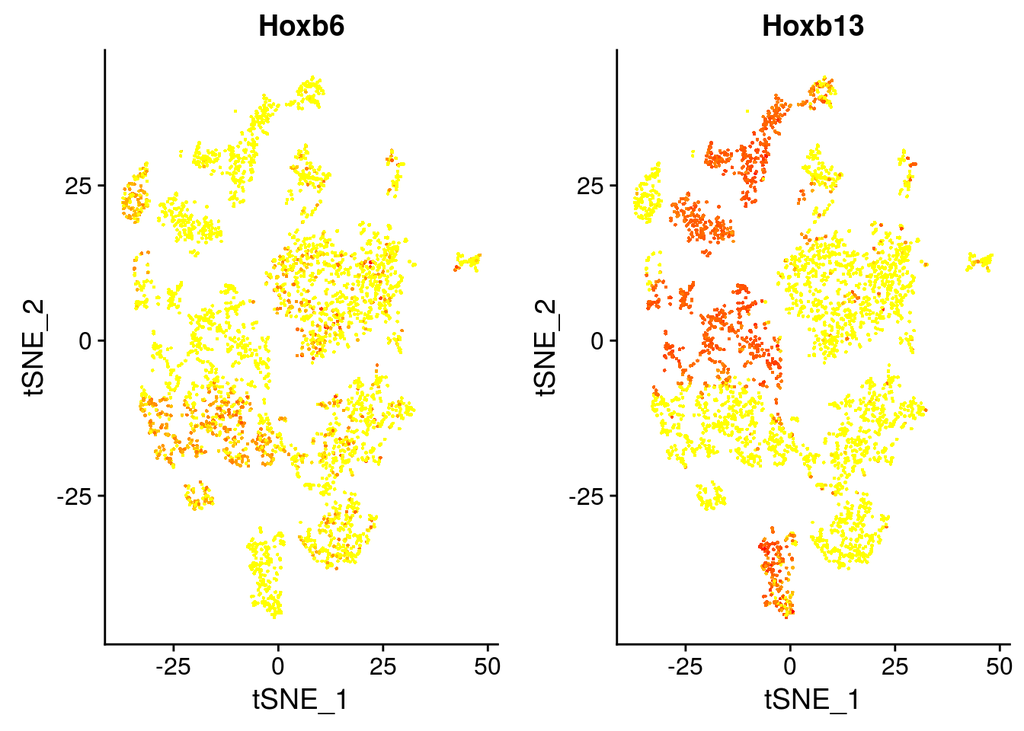

```r
#FeaturePlot(tiss, genes_to_check, pt.size = 1, nCol = 3)
FeaturePlot(tiss, c('Hoxb6', 'Hoxb13'), pt.size = 0.5)
```

Dotplots let you see the intensity of exppression and the fraction of cells expressing for each of your genes of interest.

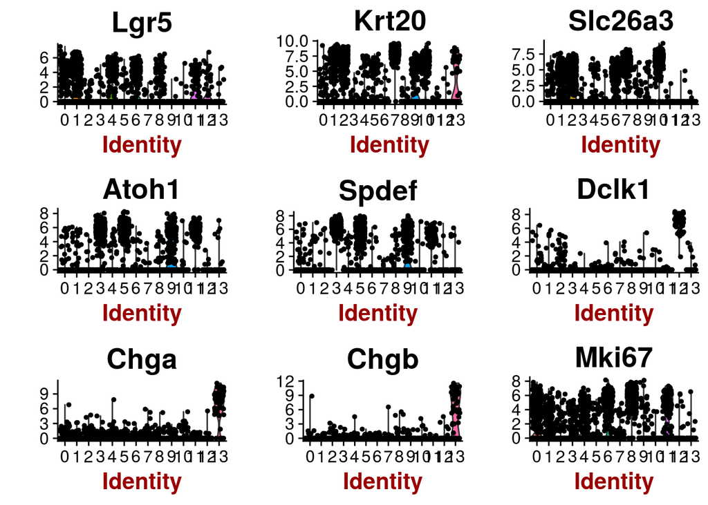

```r
# To change the y-axis to show raw counts, add use.raw = T.
VlnPlot(tiss, genes_to_check)
```

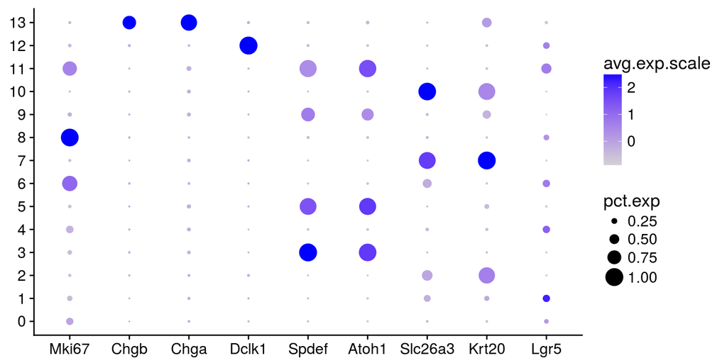

How big are the clusters?

```r
table(tiss@ident)
```

```
  0   1   2   3   4   5   6   7   8   9  10  11  12  13
625 507 450 338 294 281 278 277 251 210 201 105  62  59
```

Which markers identify a specific cluster?

```r
#clust.markers <- FindMarkers(object = tiss, ident.1 = 0, only.pos = TRUE, min.pct = 0.25, thresh.use = 0.25)
```

```r
#print(x = head(x= clust.markers, n = 10))
```

You can also compute all markers for all clusters at once. This may take some time.

```r
#tiss.markers <- FindAllMarkers(object = tiss, only.pos = TRUE, min.pct = 0.25, thresh.use = 0.25)
```

Display the top markers you computed above.

```r
#tiss.markers %>% group_by(cluster) %>% top_n(10, avg_diff)
```

## Assigning cell type identity to clusters

At a coarse level, we can use canonical markers to match the unbiased clustering to known cell types:

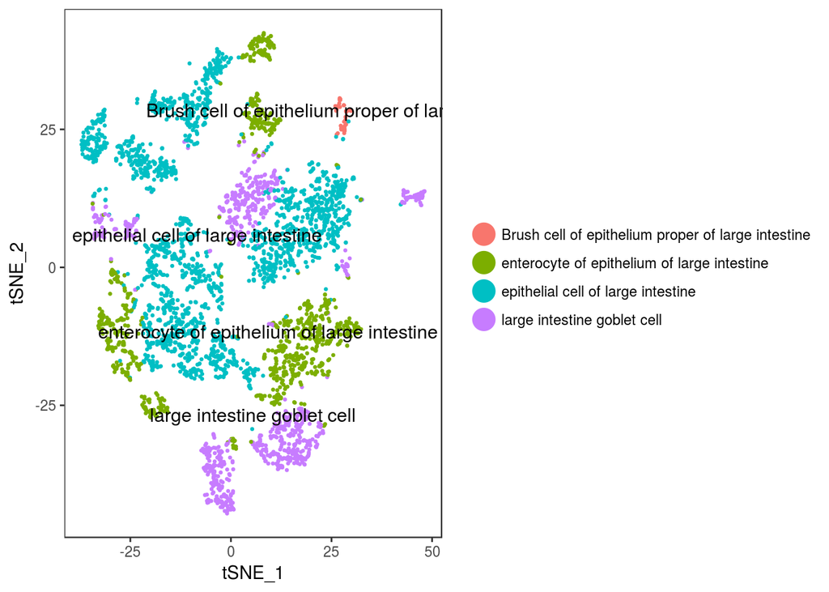

```r
# stash current cluster IDs
tiss <- StashIdent(object = tiss, save.name = "cluster.ids")

# enumerate current cluster IDs and the labels for them
cluster.ids <- c(0, 1, 2, 3, 4, 5, 6, 7, 8, 9, 10, 11, 12, 13, 14)
free_annotation <- c('Lgr5- undifferentiated cell', 'Lgr5+ undifferentiated cell (Proximal)', 'Enterocyte (Proximal)', 'Lgr5+ amplifying undifferentiated cell', 'Lgr5+ undifferentiated cell (Distal)', 'Lgr5- amplifying undifferentiated cell', 'Enterocyte (Proximal)', 'Goblet cell (Distal)', 'Goblet cell (Distal)', 'Enterocyte (Distal)', 'Goblet cell (Proximal)', 'Goblet cell (Proximal)', 'Goblet cell (Distal)', 'Tuft cell', 'Chromaffin Cell')
cell_ontology_class <-c("epithelial cell of large intestine", "epithelial cell of large intestine", "enterocyte of epithelium of large intestine", "epithelial cell of large intestine", "epithelial cell of large intestine", "epithelial cell of large intestine", "enterocyte of epithelium of large intestine", "large intestine goblet cell", "large intestine goblet cell", "enterocyte of epithelium of large intestine", "large intestine goblet cell", "large intestine goblet cell", "large intestine goblet cell", "Brush cell of epithelium proper of large intestine", "enteroendocrine cell")
cell_ontology_id <- c("CL:0002253", "CL:0002253", "CL:0002071", "CL:0002253", "CL:0002253", "CL:0002253", "CL:0002071", "CL:1000320", "CL:1000320", "CL:0002071", "CL:1000320", "CL:1000320", "CL:1000320", "CL:0002203", "CL:0000164")

tiss = stash_annotations(tiss, cluster.ids, free_annotation, cell_ontology_class)
TSNEPlot(object = tiss, do.label = TRUE, pt.size = 0.5, group.by='cell_ontology_class')
```

## Checking for batch effects

Color by metadata, like plate barcode, to check for batch effects.

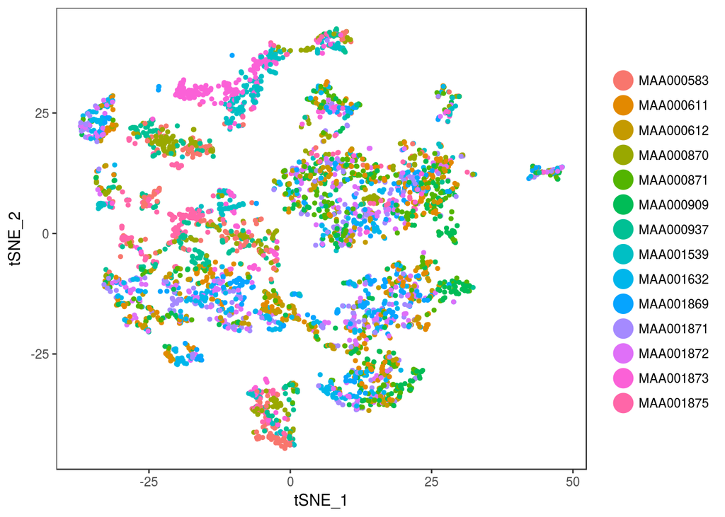

```r
TSNEPlot(object = tiss, do.return = TRUE, group.by = "plate.barcode")
```

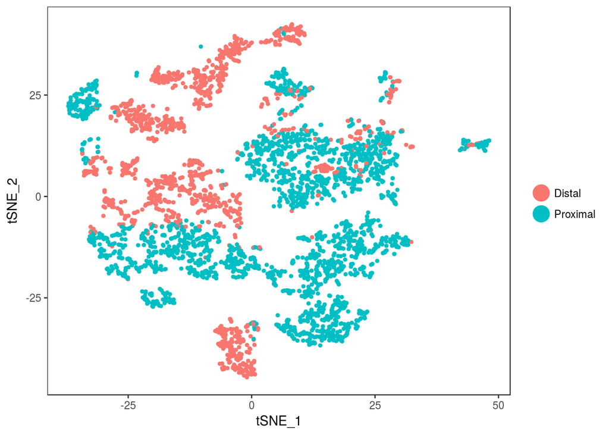

```r
TSNEPlot(object = tiss, do.return = TRUE, group.by = "subtissue")
```

Print a table showing the count of cells in each identity category from each plate.

```r
table(as.character(tiss@ident), as.character(tiss@meta.data$plate.barcode))
```

```
     MAA000583 MAA000611 MAA000612 MAA000870 MAA000871 MAA000909 MAA000937
  0          7        83        42        31       102        85         4
  1          4        68        74         3        24        24        38
  10        66         0         1        32         1         1        29
  11        22         1         1        13         4         1        12
  12         0         2         3         2        11         6         3
  13         3         5         2         5         8         5         2
  2          0        55        48         1        35        80         7
  3         48        18        10        70         6        10        62
  4         53         0         0        50         0         0        40
  5          1         0         1         7         0         0         2
  6          6        37        37         6        15        21        13
  7          0        36        23         0        51        47         0
  8          3        12        40        11        46        44         3
  9         13         6         8        24        26        10        16
```

[output cut: 16 more lines]

# Saving

```r
filename = here('00_data_ingest', '04_tissue_robj_generated',
                     paste0("facs_", tissue_of_interest, "_seurat_tiss.Robj"))
print(filename)
```

```
[1] "/home/rstudio/tabula-muris/00_data_ingest/04_tissue_robj_generated/facs_Colon_seurat_tiss.Robj"
```

```r
save(tiss, file=filename)
```

```r
# To reload a saved object
# filename = here('00_data_ingest', '04_tissue_robj_generated',
#                      paste0("facs", tissue_of_interest, "_seurat_tiss.Robj"))
# load(file=filename)
```

# Export the final metadata

So that Biohub can easily combine all your cell_ontology_classs, please export them as a simple csv.

```r
head(tiss@meta.data)
```

| nGene | nReads | orig.ident | plate.barcode | mouse.id | tissue | subtissue | FACS.selection | mouse.sex | percent.ercc | free_annotation | cell_ontology_class | percent.ribo | res.0.7 | cluster.ids | cell_ontology_id |
| --- | --- | --- | --- | --- | --- | --- | --- | --- | --- | --- | --- | --- | --- | --- | --- |
| 5464 | 581957 | Colon | MAA000583 | 3_9_M | Colon | Distal | Multiple | M | 0.005269725 | Lgr5+ undifferentiated cell (Proximal) | epithelial cell of large intestine | 0.04238114 | 1 | 1 | CL:0002253 |
| 5383 | 1233066 | Colon | MAA000611 | 3_8_M | Colon | Proximal | Multiple | M | 0.005027048 | Lgr5+ undifferentiated cell (Proximal) | epithelial cell of large intestine | 0.03527305 | 1 | 1 | CL:0002253 |
| 6846 | 1289440 | Colon | MAA000612 | 3_9_M | Colon | Proximal | Multiple | M | 0.002403781 | Lgr5+ amplifying undifferentiated cell | epithelial cell of large intestine | 0.02483714 | 3 | 3 | CL:0002253 |
| 3801 | 856231 | Colon | MAA000871 | 3_11_M | Colon | Proximal | Multiple | M | 0.009048098 | Goblet cell (Distal) | large intestine goblet cell | 0.03820932 | 8 | 8 | CL:1000320 |
| 6267 | 1175911 | Colon | MAA000909 | 3_10_M | Colon | Proximal | Multiple | M | 0.003441607 | Lgr5+ undifferentiated cell (Proximal) | epithelial cell of large intestine | 0.03088669 | 1 | 1 | CL:0002253 |
| 6149 | 504579 | Colon | MAA000937 | 3_8_M | Colon | Distal | Multiple | M | 0.004584704 | Enterocyte (Proximal) | enterocyte of epithelium of large intestine | 0.02550047 | 6 | 6 | CL:0002071 |

```r
save_annotation_csv(tiss, tissue_of_interest, "facs")
```